# Bayesian data analysis - RStan demos with QPDs

Dmytro Perepolkin

First version 2020-09-27. Last modified 2020-09-28.

# Setup

**Load packages**

```r
library(rstan)
rstan_options(auto_write = TRUE)
options(mc.cores = ceiling(parallel::detectCores()/2))

library(bayesplot)
theme_set(bayesplot::theme_default(base_family = "sans"))
SEED <- 42 # set random seed for reproducability
```

# 1 Introduction

This notebook takes from BDA [`rstan` examples by Aki Vehtari and Markus Paasiniemi](http://avehtari.github.io/BDA_R_demos/demos_rstan/rstan_demo.html) with modified [Stan](https://mc-stan.org) code to use Quantile-Parametrized Distributions (QPDs).

# 2 Bernoulli model

Toy data with sequence of failures (0) and successes (1). We would like to learn about the unknown probability of success.

```r
data_bern <- list(N = 10,
                  y = c(1, 1, 1, 0, 1, 1, 1, 0, 1, 0))
```

Original example provided Bernoulli model with a proper Beta(1,1) (uniform) prior. Since only metalog distribution is flexible enough provide something resembling the uniform distriubition, we will draw samples from fairly flat *bounded* distribution using Myerson and, then, Johnson QPDs.

```stan
#include ../quantile_functions.stan
// Bernoulli model with JQPDB_icdf
data {
  int<lower=0> N;              // number of observations
  int<lower=0,upper=1> y[N];   // vector of binary observations
  real<lower = 0, upper = 0.5> alpha;   // low is the alpha quantile
  real<lower=0, upper=1> low; // probability of success
  real<lower=low, upper=1> median;
  real<lower=median, upper=1> high;
}

parameters {
  real<lower = 0, upper = 1> p; // primitive with implicit uniform prior
}

transformed parameters {
  real theta = JQPDB_icdf(p, [0.0, 1.0], alpha, [low, median, high]'); // prior
}

model {
  // model block creates the log density to be sampled
  // theta ~ beta(1, 1);          // prior
  y ~ bernoulli(theta);        // observation model / likelihood
}
```

Sample form the posterior and show the summary

```r
data_par_bern <- c(data_bern, list(alpha=0.1, low=0.1, median=0.55, high=0.9))
bern_fit <- sampling(bern_mod1, data=data_par_bern, iter=1000, chains=4, seed=SEED)
bern_fit
```

[output not shown]

Plot the histogram of the posterior draws

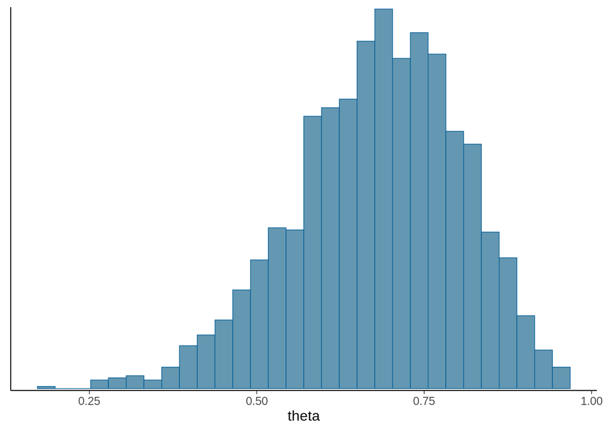

```r
draws <- as.data.frame(bern_fit)
bayesplot::mcmc_hist(draws, pars='theta')
```

```r
# or with base R
# hist(draws[,'theta'])
```

# 3 Binomial model

Instead of sequence of 0’s and 1’s, we can summarize the data with the number of experiments and the number successes:

```r
data_bin <- list(N = 10, y = 7)
```

```stan
#include ../quantile_functions.stan
// Binomial model with Myerson prior
data {
  int<lower=0> N;              // number of experiments
  int<lower=0> y;              // number of successes
  real<lower = 0, upper = 0.5> alpha;   // low is the alpha quantile
  real<lower=0, upper=1> low; // probability of success
  real<lower=low, upper=1> median;
  real<lower=median, upper=1> high;
}

parameters {
  real<lower = 0, upper = 1> p; // primitive with implicit uniform prior
}

transformed parameters {
  real theta = Myerson_icdf(p, [0.0, 1.0], alpha, [low, median, high]'); // prior
}
model {
  // model block creates the log density to be sampled
  //theta ~ beta(1, 1);          // prior
  y ~ binomial(N, theta);      // observation model / likelihood
}
```

Sample from the posterior and plot the posterior. The histogram should look similar as in the Bernoulli case.

```r
data_par_bin <- c(data_bin, list(alpha=0.1, low=0.1, median=0.55, high=0.9))
binom_fit <- sampling(binom_mod1, data=data_par_bin, iter=1000, chains=4, seed=SEED)
binom_fit
```

```
Inference for Stan model: 23da4216c51251cebf75aa69d022023f.
4 chains, each with iter=1000; warmup=500; thin=1;
post-warmup draws per chain=500, total post-warmup draws=2000.

       mean se_mean   sd  2.5%   25%   50%   75% 97.5% n_eff Rhat
p      0.65    0.01 0.15  0.34  0.55  0.67  0.76  0.88   818    1
theta  0.67    0.00 0.12  0.42  0.59  0.68  0.76  0.88   807    1
lp__  -8.09    0.02 0.64 -9.91 -8.25 -7.84 -7.67 -7.62  1073    1

Samples were drawn using NUTS(diag_e) at Mon Sep 28 16:45:57 2020.
For each parameter, n_eff is a crude measure of effective sample size,
and Rhat is the potential scale reduction factor on split chains (at
convergence, Rhat=1).
```

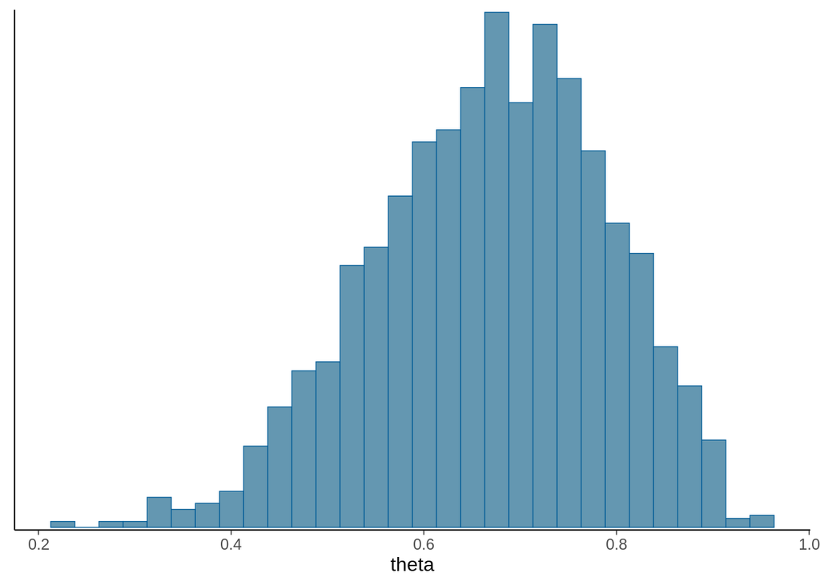

```r
draws <- as.data.frame(binom_fit)
bayesplot::mcmc_hist(draws, pars = 'theta')
```

Re-run the model with a new data. The compiled Stan program is re-used making the re-use faster.

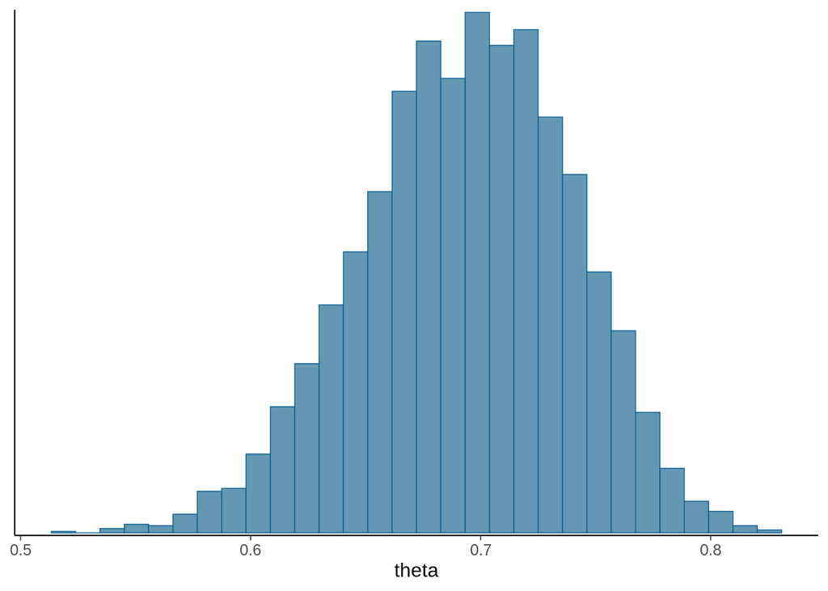

```r
data_bin <- list(N = 100, y = 70)
data_par_bin <- c(data_bin, list(alpha=0.1, low=0.1, median=0.55, high=0.9))
binom_fit <- sampling(binom_mod1, data=data_par_bin, iter=2000, chains=4, seed=SEED)
draws <- as.data.frame(binom_fit)
bayesplot::mcmc_hist(draws, pars = 'theta')
```

# 4 Comparison of two groups with Binomial

An experiment was performed to estimate the effect of beta-blockers on mortality of cardiac patients. A group of patients were randomly assigned to treatment and control groups:

- out of 674 patients receiving the control, 39 died
- out of 680 receiving the treatment, 22 died

Data:

```r
data_bin2 <- list(N1 = 674, y1 = 39, N2 = 680, y2 = 22)
```

To analyse whether the treatment is useful, we can use Binomial model for both groups and compute odds-ratio:

```stan
#include ../quantile_functions.stan
//  Comparison of two groups with Binomial and Metalog priors
data {
  int<lower=0> N1;              // number of experiments in group 1
  int<lower=0> y1;              // number of deaths in group 1
  int<lower=0> N2;              // number of experiments in group 2
  int<lower=0> y2;              // number of deaths in group 2
  real<lower = 0, upper = 0.5> alpha1;   // low1 is the alpha quantile for group 1
  real<lower = 0, upper = 0.5> alpha2;   // low2 is the alpha quantile for group 2
  vector[3] quantiles1; // three quantiles for group1
  vector[3] quantiles2; // three quantiles for group2
}
parameters {
//  real<lower=0,upper=1> theta1; // probability of death in group 1
//  real<lower=0,upper=1> theta2; // probability of death in group 2
  real<lower = 0, upper = 1> p1; // primitive with implicit uniform prior
  real<lower = 0, upper = 1> p2; // primitive with implicit uniform prior
}

transformed parameters {
  real theta1 = metalogSPTB_icdf(p1, [0.0, 1.0], alpha1, quantiles1); // prior
  real theta2 = metalogSPTB_icdf(p2, [0.0, 1.0], alpha2, quantiles2); // prior
}
model {
  // model block creates the log density to be sampled
  //theta1 ~ beta(1, 1);          // prior
  //theta2 ~ beta(1, 1);          // prior
  y1 ~ binomial(N1, theta1);    // observation model / likelihood
  y2 ~ binomial(N2, theta2);    // observation model / likelihood
}
generated quantities {
  // generated quantities are computed after sampling
  real oddsratio = (theta2/(1-theta2))/(theta1/(1-theta1));
}
```

Sample from the posterior and plot the posterior

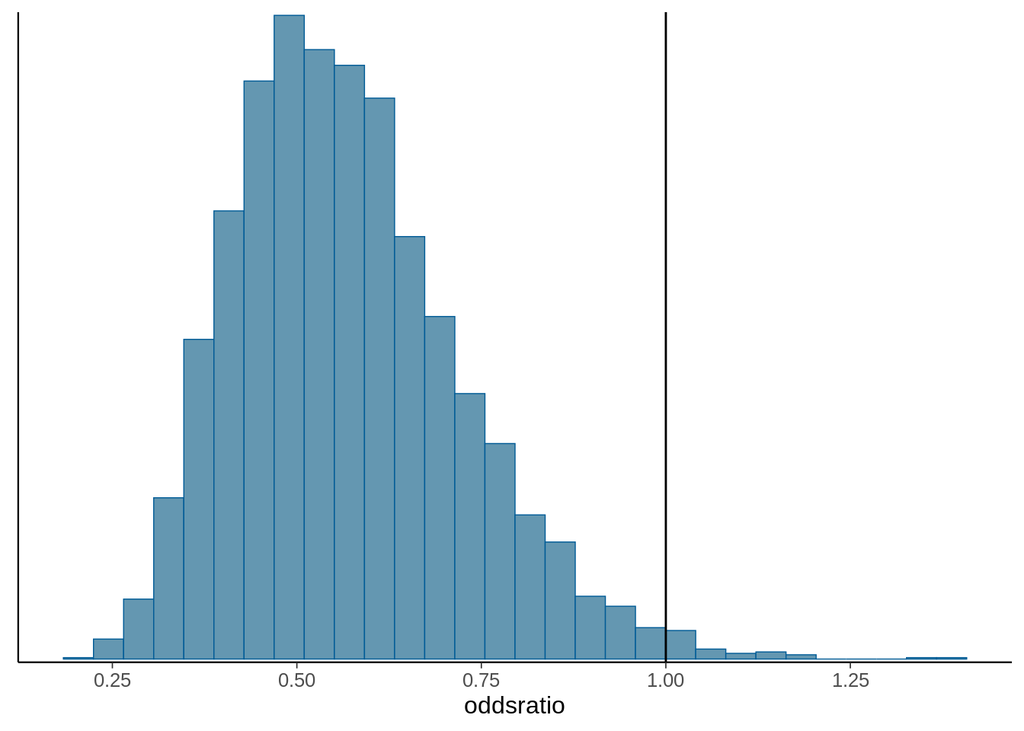

```r
data_par_bin <- c(data_bin2, list(alpha1=0.1, alpha2=0.1,
                                 quantiles1=c(0.1, 0.55, 0.9),
                                 quantiles2=c(0.1, 0.55, 0.9)))

fit_bin2 <- sampling(bin2_mod, data=data_par_bin, iter=2000, chains=4, seed=SEED)

draws <- as.data.frame(fit_bin2)
bayesplot::mcmc_hist(draws, pars = 'oddsratio') +
  geom_vline(xintercept = 1) +
  scale_x_continuous(breaks = c(seq(0.25,1.5,by=0.25)))
```

# Licenses

- Code © 2020, Dmytro Perepolkin, 2018-2020 Bob Goodrich licensed under BSD-3.
- Code © 2017-2020, Aki Vehtari, 2017 Markus Paasiniemi, licensed under BSD-3.
- Text © 2017-2020, Aki Vehtari, licensed under CC-BY-NC 4.0.